# # Red Wine Alaysis

```
##   X fixed.acidity volatile.acidity citric.acid residual.sugar chlorides
## 1 1           7.4             0.70        0.00            1.9     0.076
## 2 2           7.8             0.88        0.00            2.6     0.098
## 3 3           7.8             0.76        0.04            2.3     0.092
## 4 4          11.2             0.28        0.56            1.9     0.075
## 5 5           7.4             0.70        0.00            1.9     0.076
## 6 6           7.4             0.66        0.00            1.8     0.075
##   free.sulfur.dioxide total.sulfur.dioxide density   pH sulphates alcohol
## 1                  11                   34  0.9978 3.51      0.56     9.4
## 2                  25                   67  0.9968 3.20      0.68     9.8
## 3                  15                   54  0.9970 3.26      0.65     9.8
## 4                  17                   60  0.9980 3.16      0.58     9.8
## 5                  11                   34  0.9978 3.51      0.56     9.4
## 6                  13                   40  0.9978 3.51      0.56     9.4
##   quality
## 1       5
## 2       5
## 3       5
## 4       6
## 5       5
## 6       5
```

```r
names(wine)
```

```
##  [1] "X"                    "fixed.acidity"        "volatile.acidity"
##  [4] "citric.acid"          "residual.sugar"       "chlorides"
##  [7] "free.sulfur.dioxide"  "total.sulfur.dioxide" "density"
## [10] "pH"                   "sulphates"            "alcohol"
## [13] "quality"
```

```r
summary(wine)
```

```
##        X          fixed.acidity   volatile.acidity  citric.acid
##  Min.   :   1.0   Min.   : 4.60   Min.   :0.1200   Min.   :0.000
##  1st Qu.: 400.5   1st Qu.: 7.10   1st Qu.:0.3900   1st Qu.:0.090
##  Median : 800.0   Median : 7.90   Median :0.5200   Median :0.260
##  Mean   : 800.0   Mean   : 8.32   Mean   :0.5278   Mean   :0.271
##  3rd Qu.:1199.5   3rd Qu.: 9.20   3rd Qu.:0.6400   3rd Qu.:0.420
##  Max.   :1599.0   Max.   :15.90   Max.   :1.5800   Max.   :1.000
##  residual.sugar     chlorides       free.sulfur.dioxide
##  Min.   : 0.900   Min.   :0.01200   Min.   : 1.00
##  1st Qu.: 1.900   1st Qu.:0.07000   1st Qu.: 7.00
##  Median : 2.200   Median :0.07900   Median :14.00
##  Mean   : 2.539   Mean   :0.08747   Mean   :15.87
##  3rd Qu.: 2.600   3rd Qu.:0.09000   3rd Qu.:21.00
##  Max.   :15.500   Max.   :0.61100   Max.   :72.00
##  total.sulfur.dioxide    density             pH          sulphates
##  Min.   :  6.00       Min.   :0.9901   Min.   :2.740   Min.   :0.3300
##  1st Qu.: 22.00       1st Qu.:0.9956   1st Qu.:3.210   1st Qu.:0.5500
##  Median : 38.00       Median :0.9968   Median :3.310   Median :0.6200
##  Mean   : 46.47       Mean   :0.9967   Mean   :3.311   Mean   :0.6581
##  3rd Qu.: 62.00       3rd Qu.:0.9978   3rd Qu.:3.400   3rd Qu.:0.7300
##  Max.   :289.00       Max.   :1.0037   Max.   :4.010   Max.   :2.0000
##     alcohol         quality
##  Min.   : 8.40   Min.   :3.000
##  1st Qu.: 9.50   1st Qu.:5.000
##  Median :10.20   Median :6.000
##  Mean   :10.42   Mean   :5.636
##  3rd Qu.:11.10   3rd Qu.:6.000
##  Max.   :14.90   Max.   :8.000
```

In this project i am going to analys the data of red wines quality so that i can know what type of wines comes to the market, And know about the content and what are precaoutions needed to make the red wine good.

# Univariate Plots Section

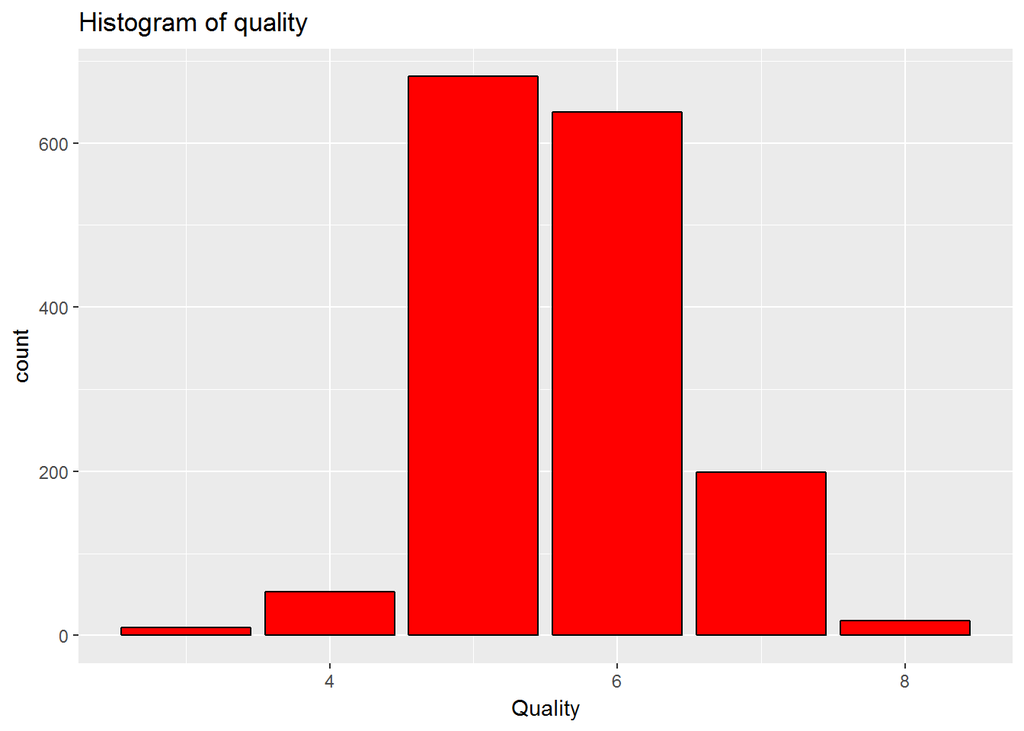

```r
#quality

ggplot(aes(x = quality),data = wine) +
  ggtitle('Histogram of quality') +
  ylab('count') +
  xlab('Quality') +
  geom_histogram(stat = 'count',color = 'black', fill = 'red')
```

```r
# summary
summary(wine$quality)
```

```
##    Min. 1st Qu.  Median    Mean 3rd Qu.    Max.
##   3.000   5.000   6.000   5.636   6.000   8.000
```

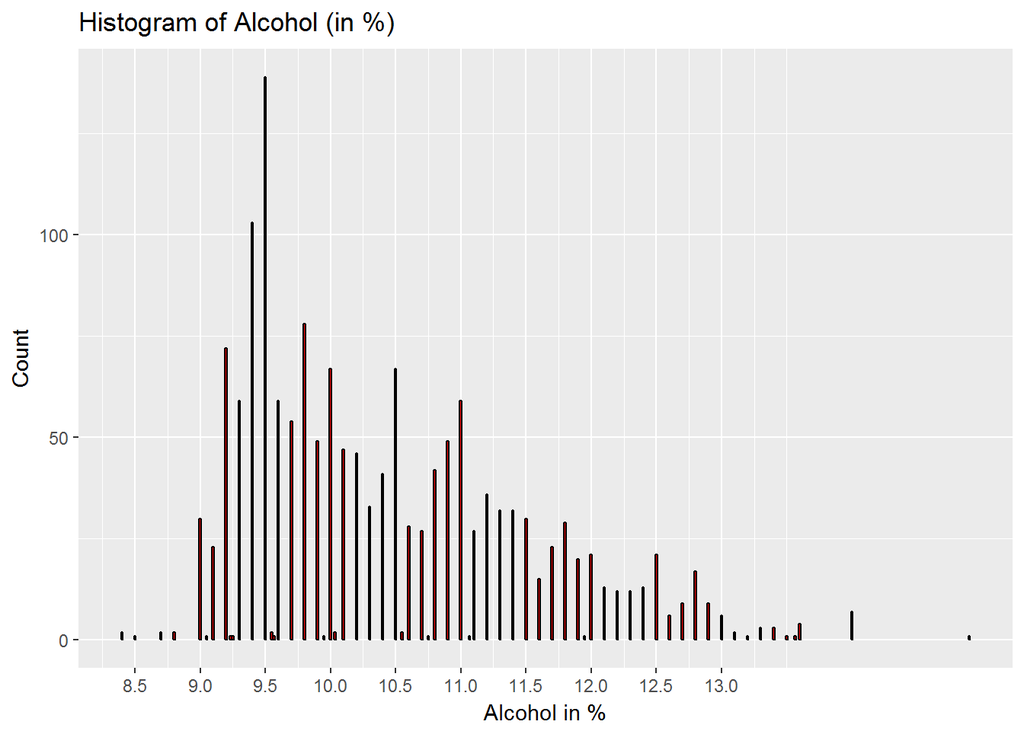

```r
#alcohol

ggplot(aes(x = alcohol),data = wine) +
  geom_histogram(stat = 'count',color = 'black', fill = 'red') +
  ggtitle('Histogram of Alcohol (in %)') +
  xlab('Alcohol in %') +
  ylab('Count') +
  scale_x_continuous(breaks = seq(8,13,0.5))
```

```r
#summary
summary(wine$alcohol)
```

```
##    Min. 1st Qu.  Median    Mean 3rd Qu.    Max.
##    8.40    9.50   10.20   10.42   11.10   14.90
```

The minimum amout of alcoho; present is 8.4% and maximum amout is presenet is 14.9%, The average amount of alcohol is present 10.42%.

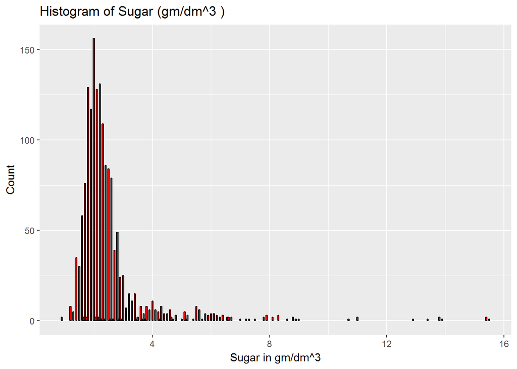

```r
#sugar

ggplot(aes(x = residual.sugar),data = wine) +
  geom_histogram(stat = 'count',color = 'black', fill = 'red') +
  ggtitle('Histogram of Sugar (gm/dm^3 )') +
  xlab('Sugar in gm/dm^3') +
  ylab('Count') +
  scale_x_continuous()
```

```r
#summary
summary(wine$residual.sugar)
```

```
##    Min. 1st Qu.  Median    Mean 3rd Qu.    Max.
##   0.900   1.900   2.200   2.539   2.600  15.500
```

The minimum amount of residual sugar present is 0.9 dm/dm^3 but there are some outliers so due to that the maximum value is 15.5gm/dm^3.

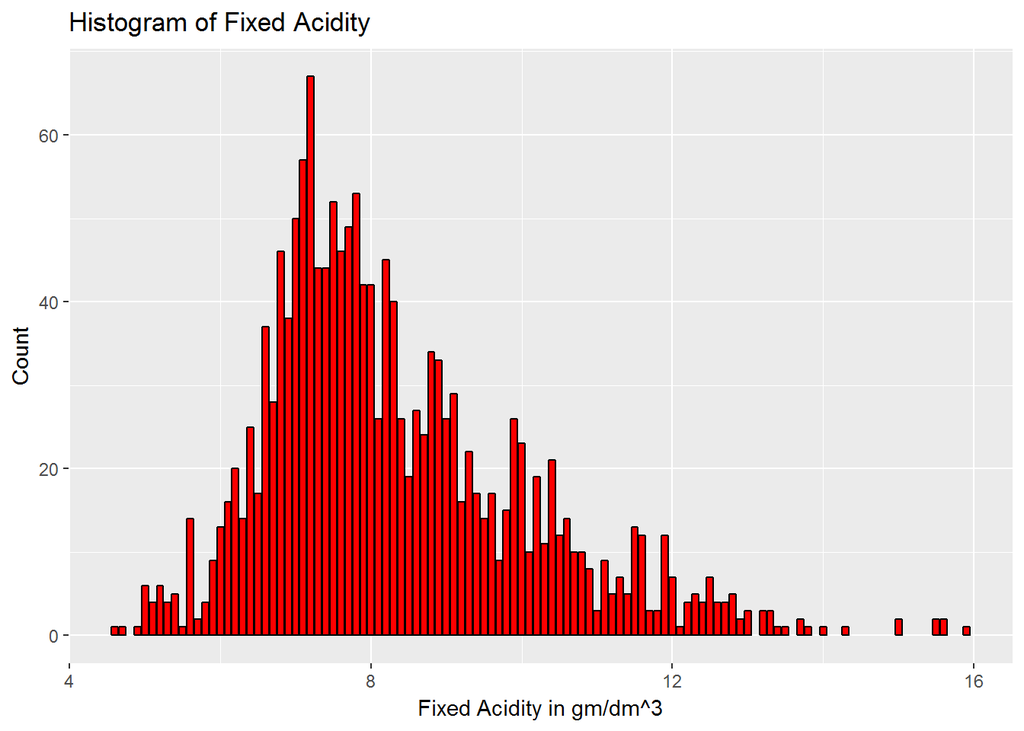

```r
#fixed acidity

ggplot(aes(x = fixed.acidity),data = wine) +
  geom_histogram(stat = 'count',color = 'black', fill = 'red') +
  ggtitle('Histogram of Fixed Acidity') +
  xlab('Fixed Acidity in gm/dm^3') +
  ylab('Count') +
  scale_x_continuous()
```

```r
#summary
summary(wine$fixed.acidity)
```

```
##    Min. 1st Qu.  Median    Mean 3rd Qu.    Max.
##    4.60    7.10    7.90    8.32    9.20   15.90
```

The minimum amount of fixed acidity in every bottle of wine is 4.6gm/dm^3 And the maximum amount is 15.90gm/dm^3.

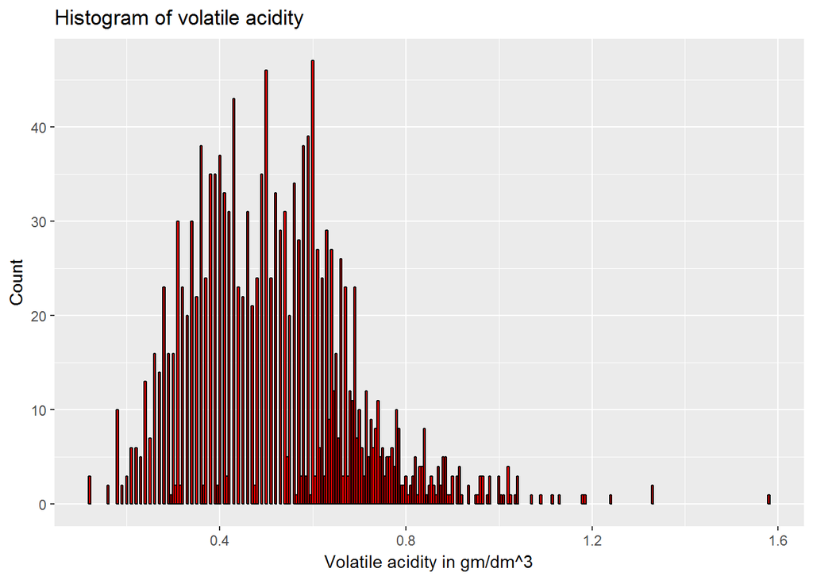

```r
# volatile acidity

ggplot(aes(x = volatile.acidity),data = wine) +
  geom_histogram(stat = 'count',color = 'black', fill = 'red') +
  ggtitle('Histogram of volatile acidity') +
  xlab('Volatile acidity in gm/dm^3') +
  ylab('Count') +
  scale_x_continuous()
```

```r
#summary
summary(wine$volatile.acidity)
```

```
##    Min. 1st Qu.  Median    Mean 3rd Qu.    Max.
##  0.1200  0.3900  0.5200  0.5278  0.6400  1.5800
```

The minimum amount of volatile acidity in every bottle is around 0.12gm/dm^3 But due to some outliers th value has reached to 1.58gm/dm^3 but it should be around 1.0

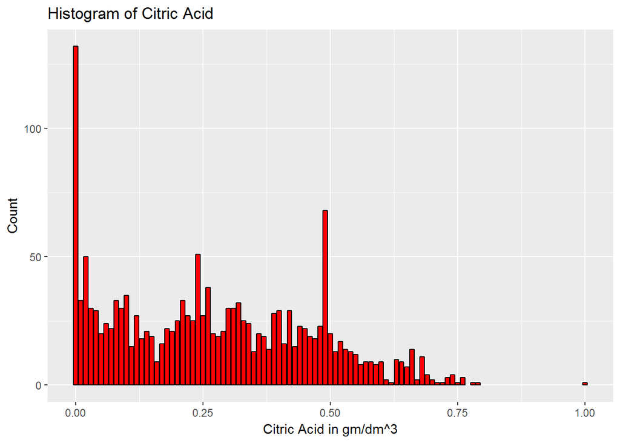

```r
#citric acid

ggplot(aes(x = citric.acid),data = wine) +
  geom_histogram(stat = 'count',color = 'black', fill = 'red') +
  ggtitle('Histogram of Citric Acid') +
  xlab('Citric Acid in gm/dm^3') +
  ylab('Count') +
  scale_x_continuous()
```

```r
# summary
summary(wine$citric.acid)
```

```
##    Min. 1st Qu.  Median    Mean 3rd Qu.    Max.
##   0.000   0.090   0.260   0.271   0.420   1.000
```

The minimum amount of citric acid present in wine is 0 and max value is 1 but this is due to some outliers.

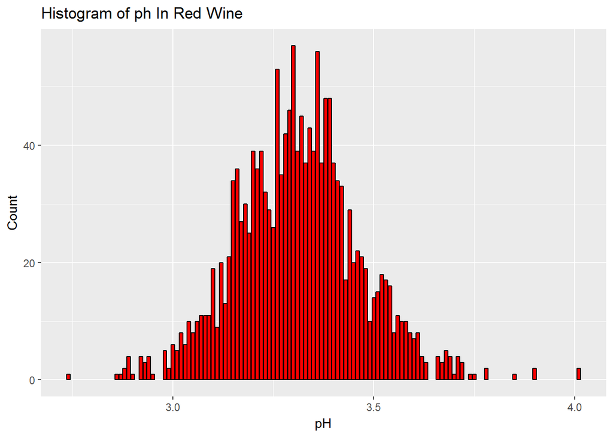

```r
#pH

ggplot(aes(x = pH),data = wine) +
  geom_histogram(stat = 'count',color = 'black', fill = 'red') +
  ggtitle('Histogram of ph In Red Wine') +
  xlab('pH') +
  ylab('Count') +
  scale_x_continuous()
```

```r
# summary
summary(wine$pH)
```

```
##    Min. 1st Qu.  Median    Mean 3rd Qu.    Max.
##   2.740   3.210   3.310   3.311   3.400   4.010
```

Minimum pH of red wine is 2.740 and the max value is 4.010

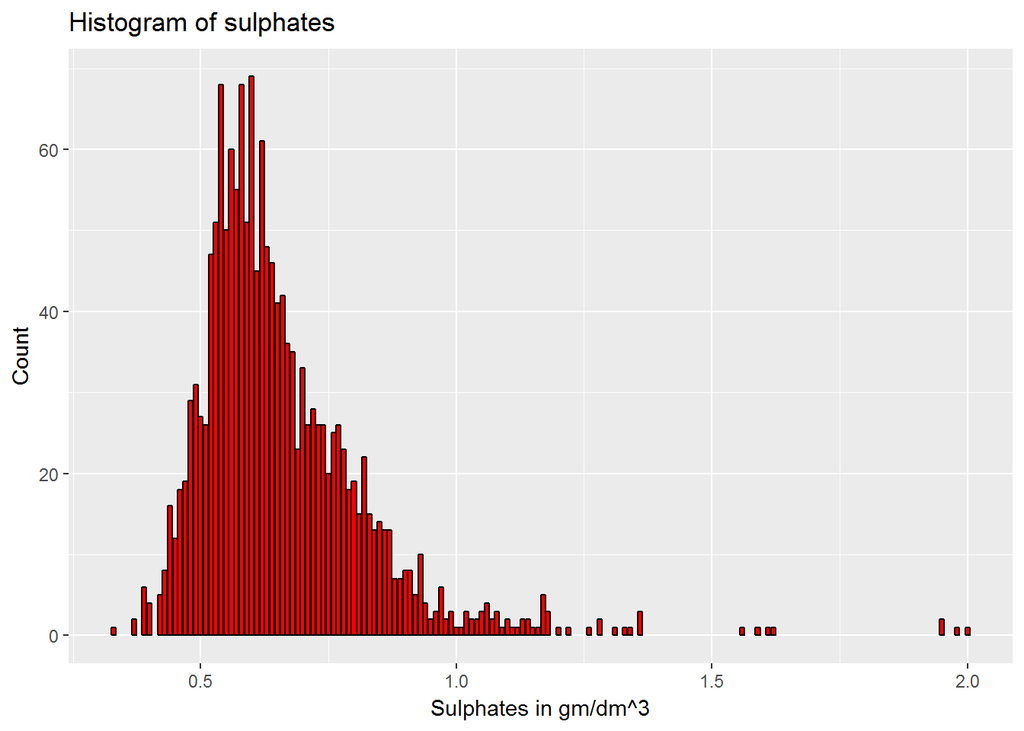

```r
#Sulphates

ggplot(aes(x = sulphates),data = wine) +
  geom_histogram(stat = 'count',color = 'black', fill = 'red') +
  ggtitle('Histogram of sulphates') +
  xlab('Sulphates in gm/dm^3') +
  ylab('Count') +
  scale_x_continuous()
```

```r
# summary
summary(wine$sulphates)
```

```
##    Min. 1st Qu.  Median    Mean 3rd Qu.    Max.
##  0.3300  0.5500  0.6200  0.6581  0.7300  2.0000
```

The min value is 0.33 and max value is 2 because of outliers in data.

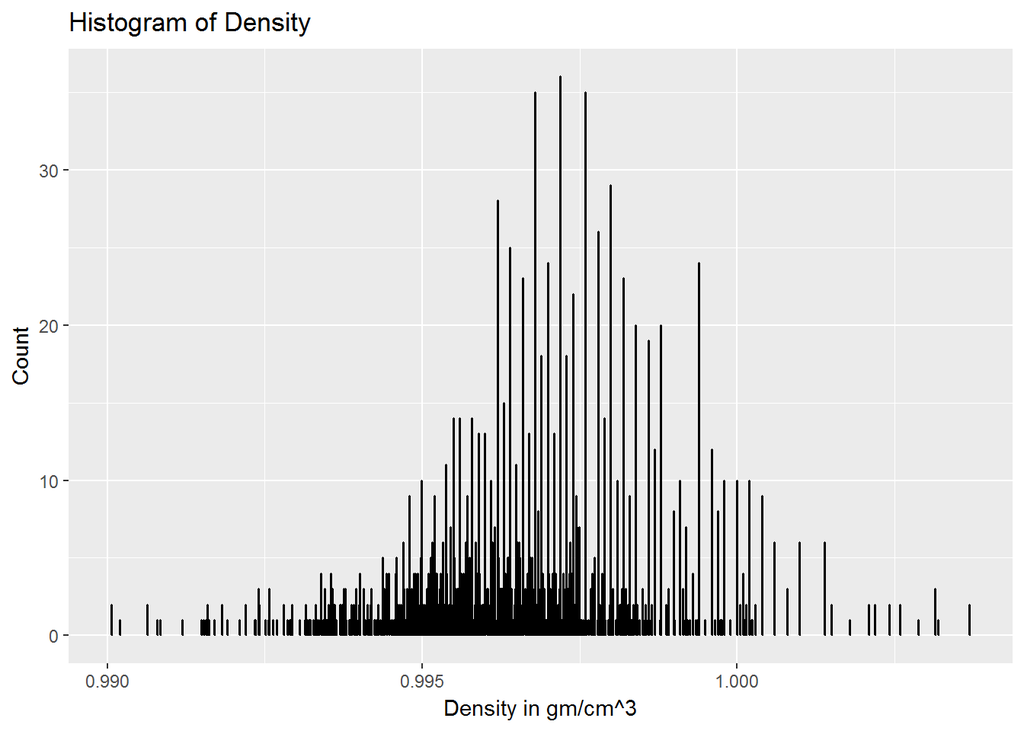

```r
#Density

ggplot(aes(x = density),data = wine) +
  geom_histogram(stat = 'count',color = 'black', fill = 'red') +
  ggtitle('Histogram of Density') +
  xlab('Density in gm/cm^3') +
  ylab('Count') +
  scale_x_continuous()
```

```r
# summary

summary(wine$density)
```

```
##    Min. 1st Qu.  Median    Mean 3rd Qu.    Max.
##  0.9901  0.9956  0.9968  0.9967  0.9978  1.0037
```

The density is around 1 only.

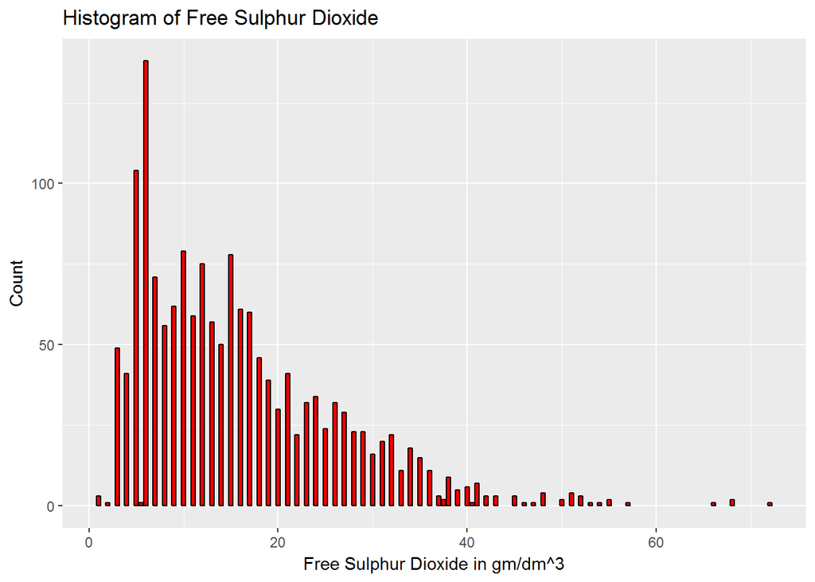

```r
# Free sulfur dioxide

ggplot(aes(x = free.sulfur.dioxide),data = wine) +
  geom_histogram(stat = 'count',color = 'black', fill = 'red') +
  ggtitle('Histogram of Free Sulphur Dioxide') +
  xlab('Free Sulphur Dioxide in gm/dm^3') +
  ylab('Count') +
  scale_x_continuous()
```

```r
# summary
summary(wine$free.sulfur.dioxide)
```

```
##    Min. 1st Qu.  Median    Mean 3rd Qu.    Max.
##    1.00    7.00   14.00   15.87   21.00   72.00
```

The minimum amount of free sulfur dioxide present is 1 and max is 72.00 butb the 3rd quadrant value is 21.00 and the mean value is 15.87

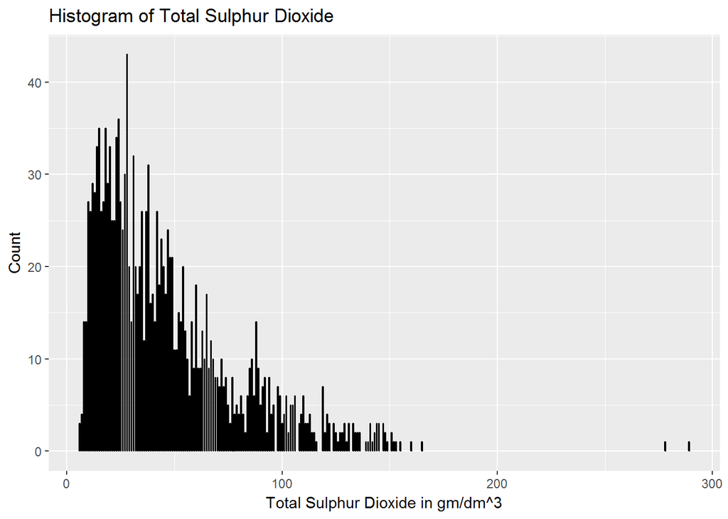

```r
#total sulphur dioxide

ggplot(aes(x = wine$total.sulfur.dioxide),data = wine) +
  geom_histogram(stat = 'count',color = 'black', fill = 'red') +
  ggtitle('Histogram of Total Sulphur Dioxide') +
  xlab('Total Sulphur Dioxide in gm/dm^3') +
  ylab('Count') +
  scale_x_continuous()
```

```r
# summary
summary(wine$total.sulfur.dioxide)
```

```
##    Min. 1st Qu.  Median    Mean 3rd Qu.    Max.
##    6.00   22.00   38.00   46.47   62.00  289.00
```

The average amount of total sulfur sioxide present is 46.47

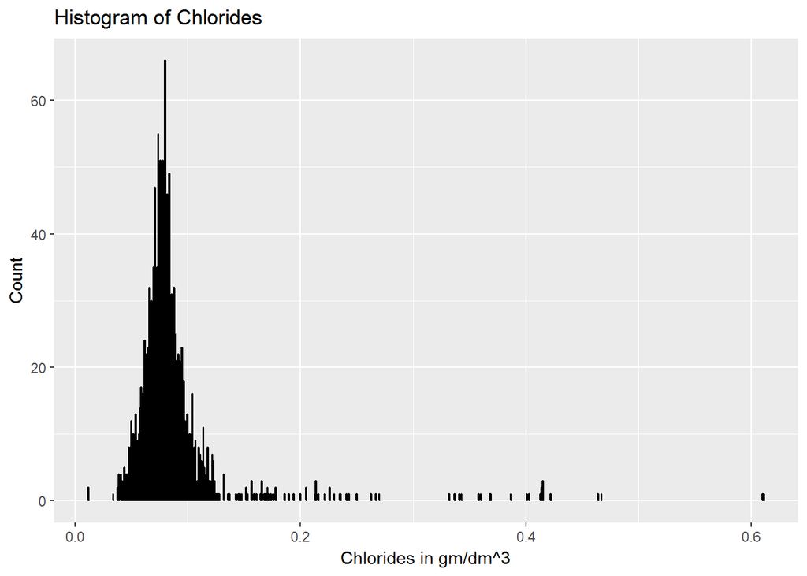

```r
#chlorides

ggplot(aes(x = chlorides),data = wine) +
  geom_histogram(stat = 'count',color = 'black', fill = 'red') +
  ggtitle('Histogram of Chlorides') +
  xlab('Chlorides in gm/dm^3') +
  ylab('Count') +
  scale_x_continuous()
```

```r
# summary
summary(wine$chlorides)
```

```
##    Min. 1st Qu.  Median    Mean 3rd Qu.    Max.
## 0.01200 0.07000 0.07900 0.08747 0.09000 0.61100
```

The chlorides mean amount prsesnt is around 0.08747

# Univariate Analysis

### What is the structure of your dataset?

In this there are 13 Variables with 1599 observations.

### What is/are the main feature(s) of interest in your dataset?

In this data set the main feature is the quality. As It will help to tell us to buy the good quality wine.

### What other features in the dataset do you think will help support your into your feature(s) of interest?

In this alcohol in %,pH,sugar,acid present in it will help me out.

### Did you create any new variables from existing variables in the dataset?

No, I haven’t create any new variable in the dataset

### Did you perform any operations on the data to tidy, adjust, or change the form of the data?

No, Ihaven’t made nay changes in the data.

# Bivariate Plots Section

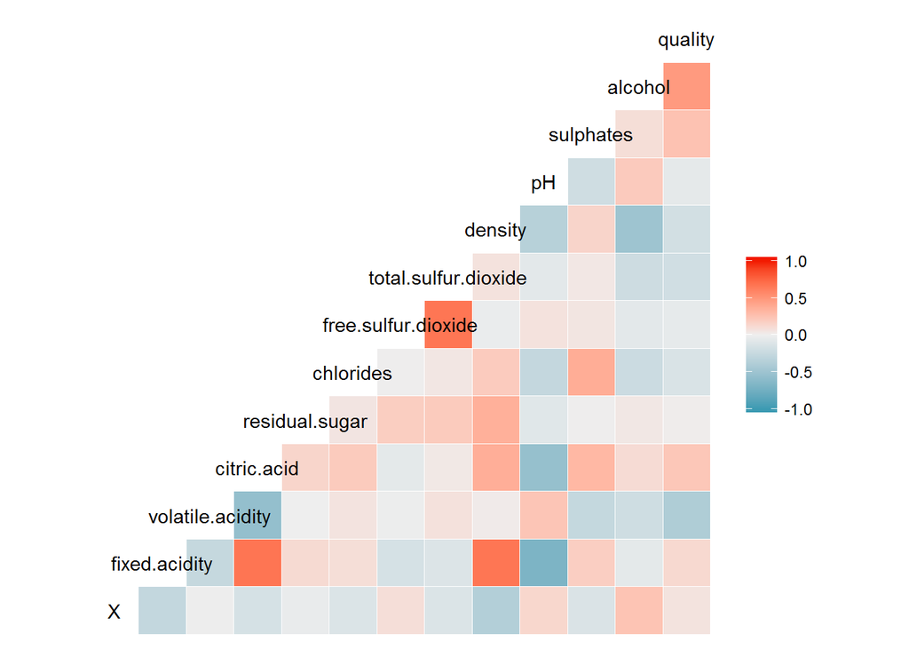

```r
ggcorr(wine)
```

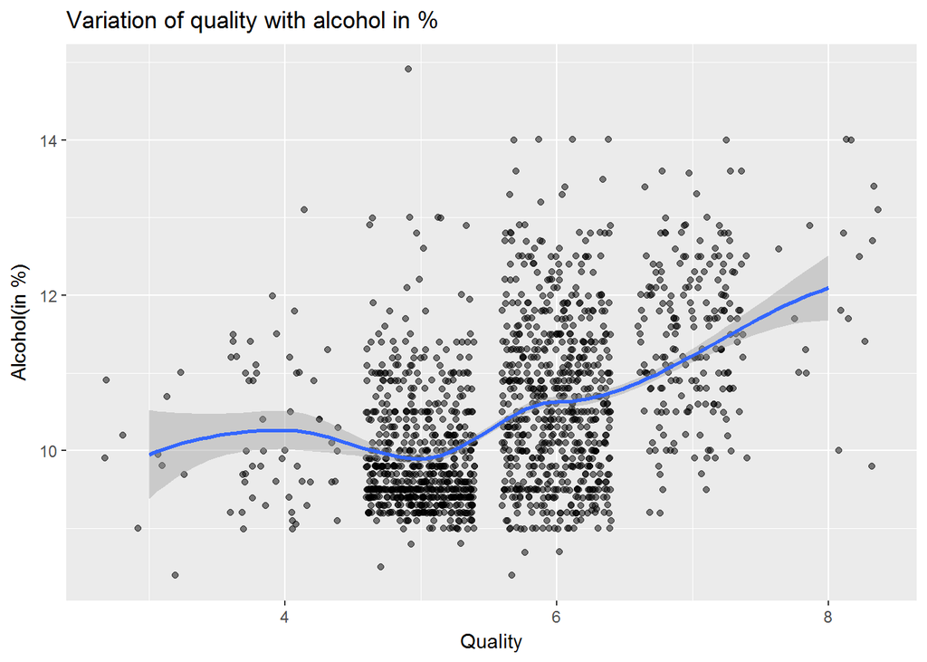

```r
#Quality vs alcohol

ggplot(aes(x = quality,y=alcohol),data = wine) +
  geom_jitter(alpha = 0.5) +
  stat_summary(fun.y = 'mean',color = 'red') +
  ggtitle('Variation of quality with alcohol in %') +
  xlab('Quality') +
  ylab('Alcohol(in %)') +
  geom_smooth(method = 'loess')
```

In this Graph they both have +ve correlation and so the alcohol % increases with the quality of wine increases.

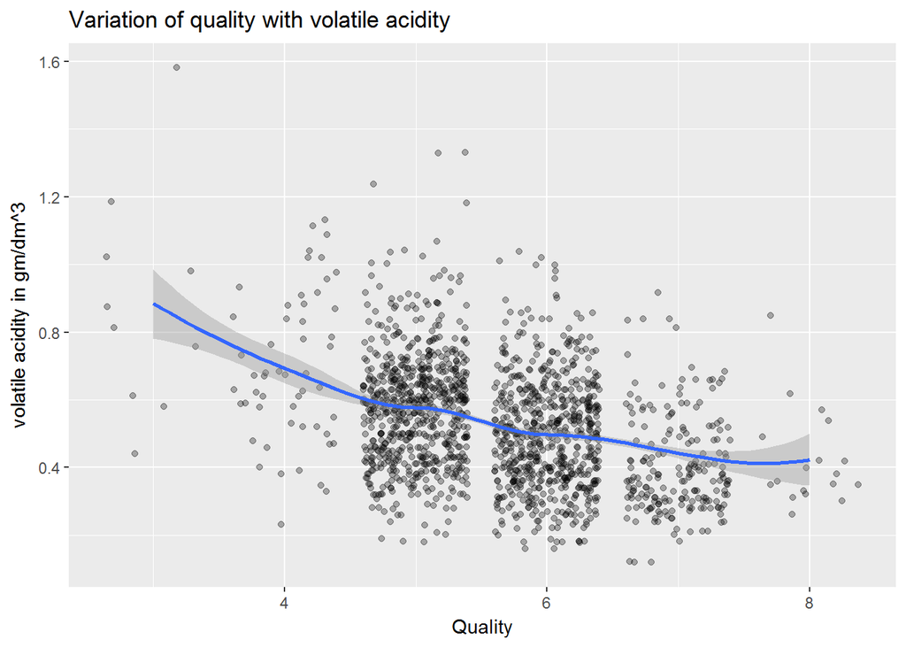

```r
#quality with volatile acidity(-ve)
ggplot(aes(x = quality,y=volatile.acidity),data = wine) +
  geom_jitter(alpha = 0.3) +
  ggtitle('Variation of quality with volatile acidity') +
  xlab('Quality') +
  ylab('volatile acidity in gm/dm^3') +
  geom_smooth(method = 'loess')
```

It is confirm there correlation is -ve as The wine quality is increasing so the volatile acidity is decreasing in wine.

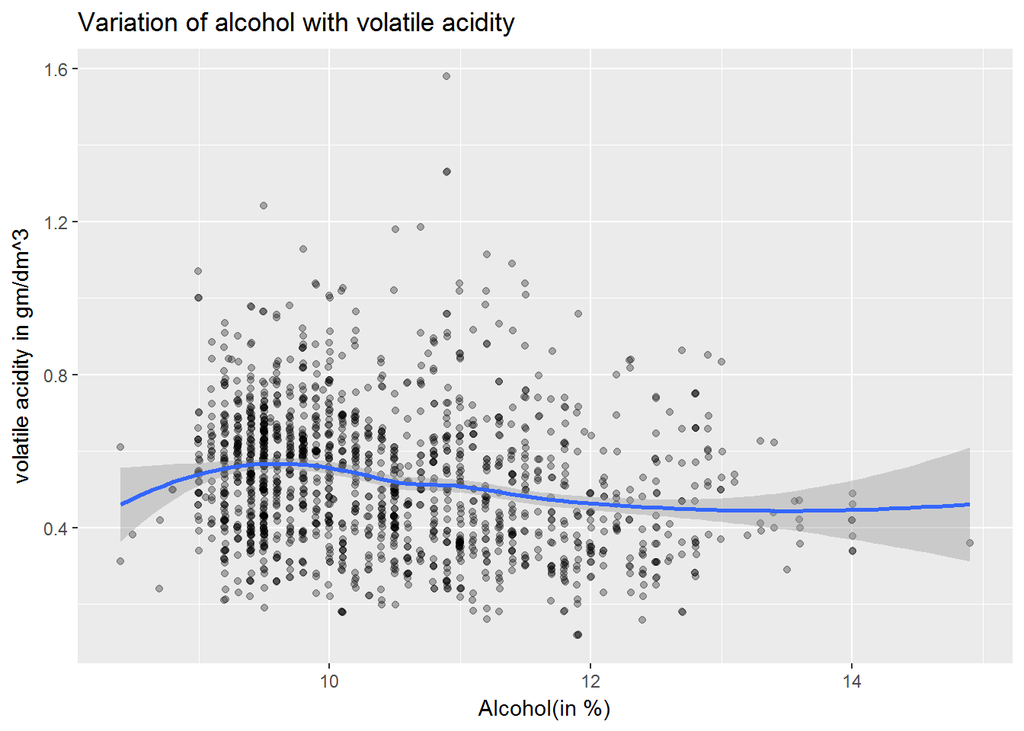

```r
#alcohol with volatile acidity(-ve)
ggplot(aes(x = alcohol,y=volatile.acidity),data = wine) +
  geom_jitter(alpha = 0.3) +
  ggtitle('Variation of alcohol with volatile acidity') +
  xlab('Alcohol(in %)') +
  ylab('volatile acidity in gm/dm^3') +
  geom_smooth(method = 'loess')
```

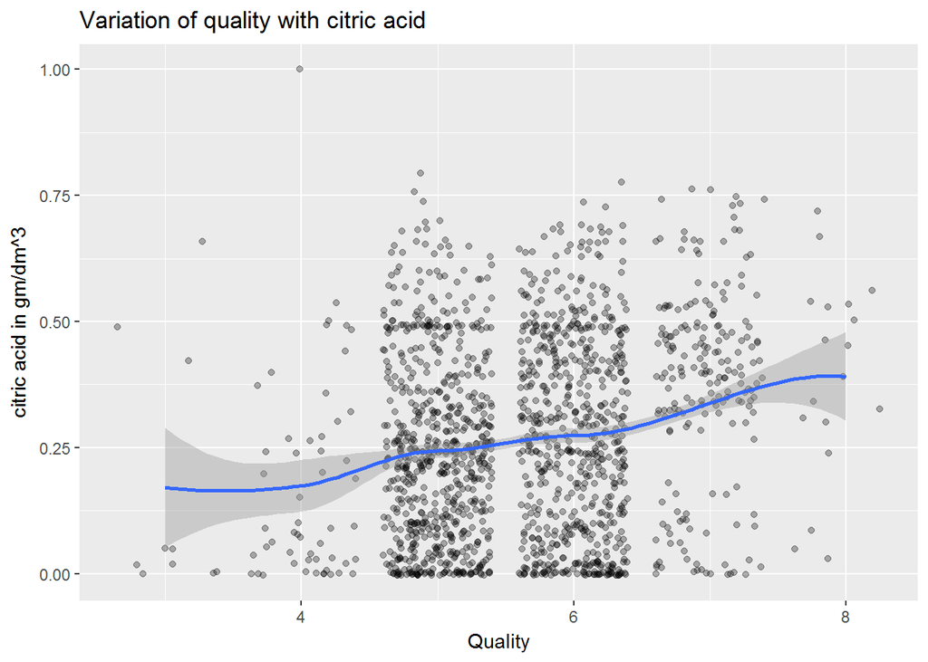

```r
#Quality with citric acid
ggplot(aes(x = quality,y=citric.acid),data = wine) +
  geom_jitter(alpha = 0.3) +
  ggtitle('Variation of quality with citric acid') +
  xlab('Quality') +
  ylab('citric acid in gm/dm^3') +
  geom_smooth(method = 'loess')
```

In this Graph, Ciric acid quantity increases as the quality of wine increases.

[figure not shown]

```r
#Quality with sulphates
ggplot(aes(x = quality,y=sulphates),data = wine) +
  geom_jitter(alpha = 0.3) +
  ggtitle('Variation of alcohol with sulphates') +
  xlab('Quality') +
  ylab('Sulphates in gm/dm^3') +
  geom_smooth(method = 'loess')
```

In this graph, Quantity of Sulphates Linearly increases with the Quality of wine increases.

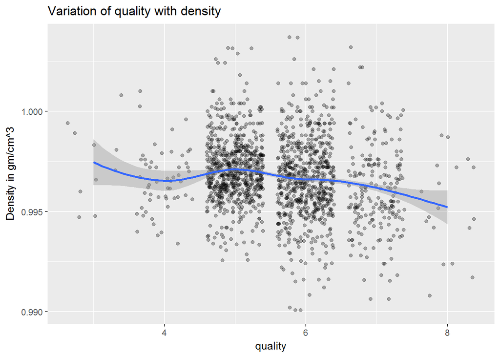

```r
#Quality with density
ggplot(aes(x = quality,y=density),data = wine) +
  geom_jitter(alpha = 0.3) +
  ggtitle('Variation of quality with density') +
  xlab('quality') +
  ylab('Density in gm/cm^3') +
  geom_smooth(method = 'loess')
```

Over here, Density decreases with the Uality marginally decreases.

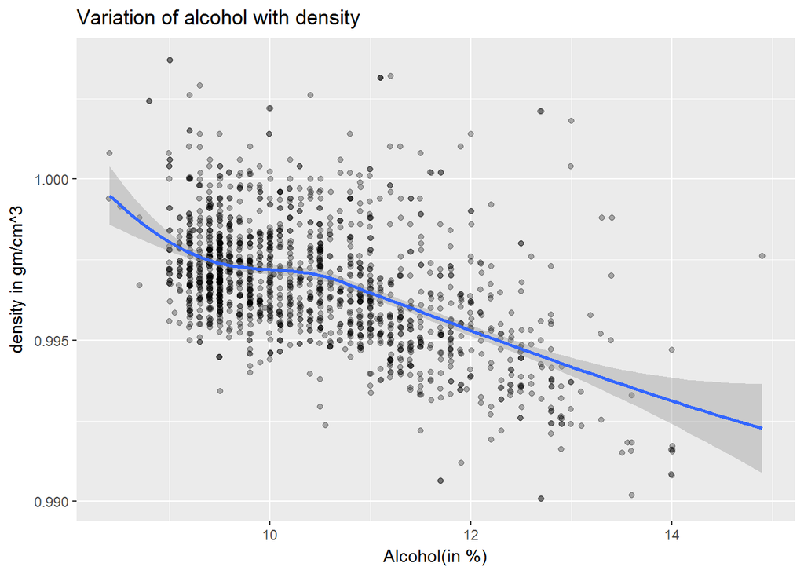

```r
#alcohol with density
ggplot(aes(x = alcohol,y=density),data = wine) +
  geom_jitter(alpha = 0.3) +
  ggtitle('Variation of alcohol with density') +
  xlab('Alcohol(in %)') +
  ylab('density in gm/cm^3') +
  geom_smooth(method = 'loess')
```

As the alcohol % increases the density of wine keeps on Decreasing.

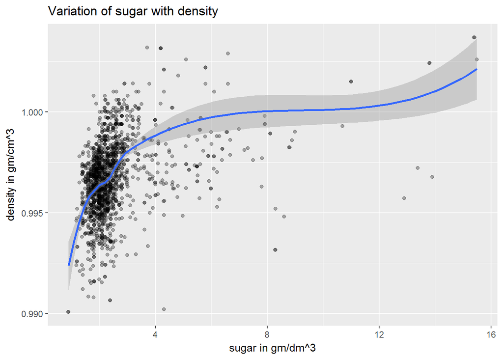

```r
#sugar with density

ggplot(aes(x = residual.sugar,y = density),data = wine) +
  geom_jitter(alpha = 0.3) +
  ggtitle('Variation of sugar with density') +
  xlab('sugar in gm/dm^3') +
  ylab('density in gm/cm^3') +
  geom_smooth(method = 'loess')
```

So, over here as quantity of sugar is increasing in wine the density of wine is also increasing.

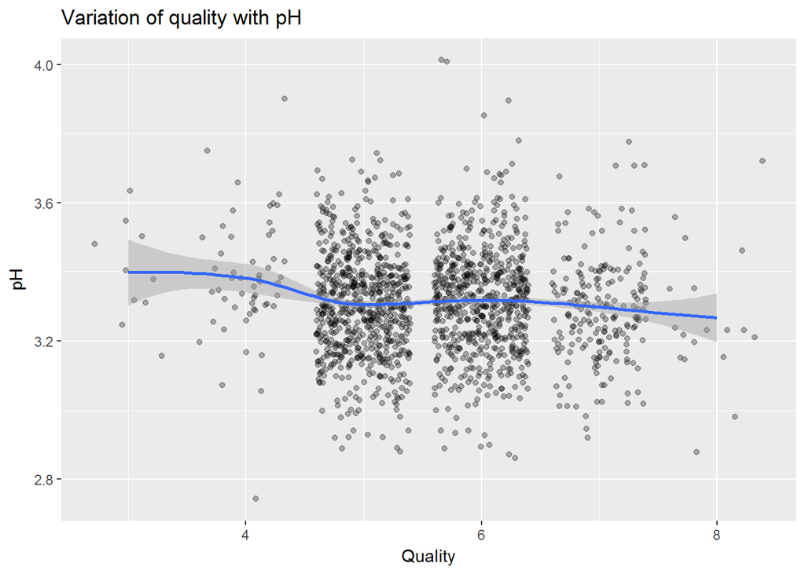

```r
#Quality with pH

ggplot(aes(x = quality,y = pH),data = wine) +
  geom_jitter(alpha = 0.3) +
  ggtitle('Variation of quality with pH') +
  xlab('Quality') +
  ylab('pH') +
  geom_smooth(method = 'loess')
```

In this Graph, Almost the pH is remained constant.

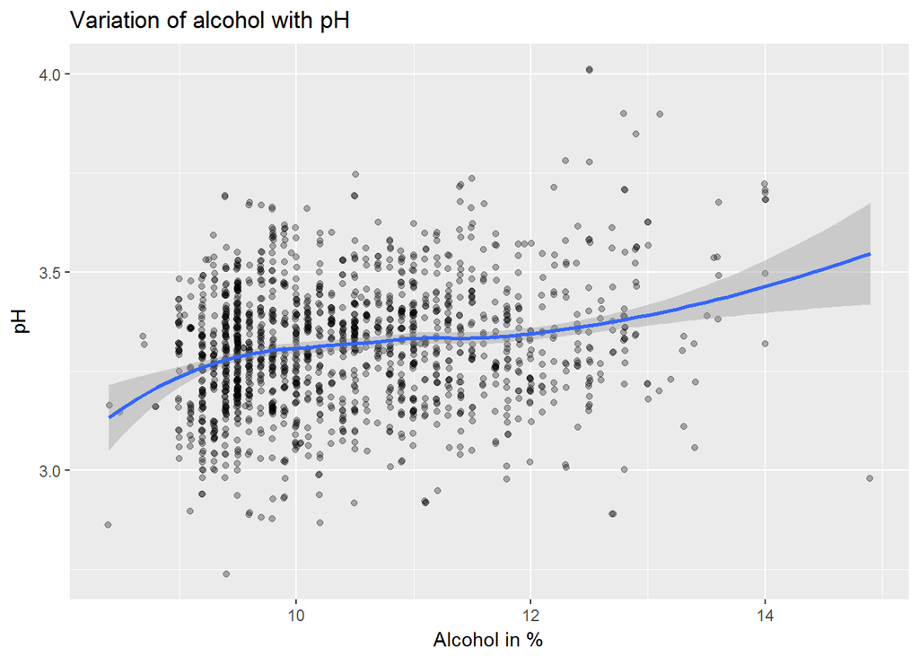

```r
#Alcohol with pH

ggplot(aes(x = alcohol,y = pH),data = wine) +
  geom_jitter(alpha = 0.3) +
  ggtitle('Variation of alcohol with pH') +
  xlab('Alcohol in %') +
  ylab('pH') +
  geom_smooth(method = 'loess')
```

With the increase of Alcohol % The pH value also inreases of wine.

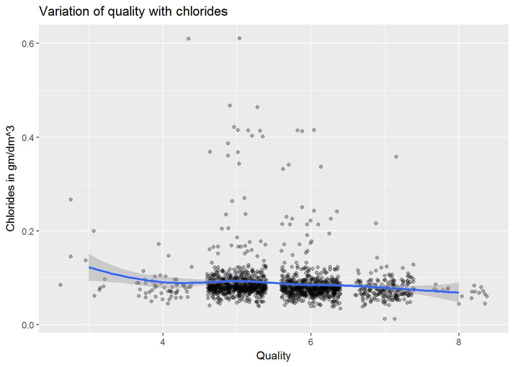

```r
#Quality with chlorides

ggplot(aes(x = quality,y = chlorides),data = wine) +
  geom_jitter(alpha = 0.3) +
  ggtitle('Variation of quality with chlorides') +
  xlab('Quality') +
  ylab('Chlorides in gm/dm^3') +
  geom_smooth(method = 'loess')
```

As the quality value changes the chlorides quantity is mostly constant.

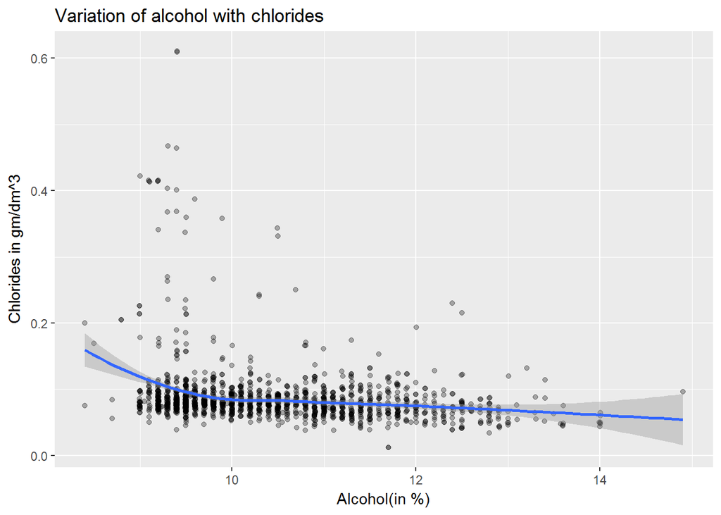

```r
#Alcohol with chlorides

ggplot(aes(x = alcohol,y = chlorides),data = wine) +
  geom_jitter(alpha = 0.3) +
  ggtitle('Variation of alcohol with chlorides') +
  xlab('Alcohol(in %)') +
  ylab('Chlorides in gm/dm^3') +
  geom_smooth(method = 'loess')
```

The chlorides quantity has decreased a little bit But after that bit remained constant.

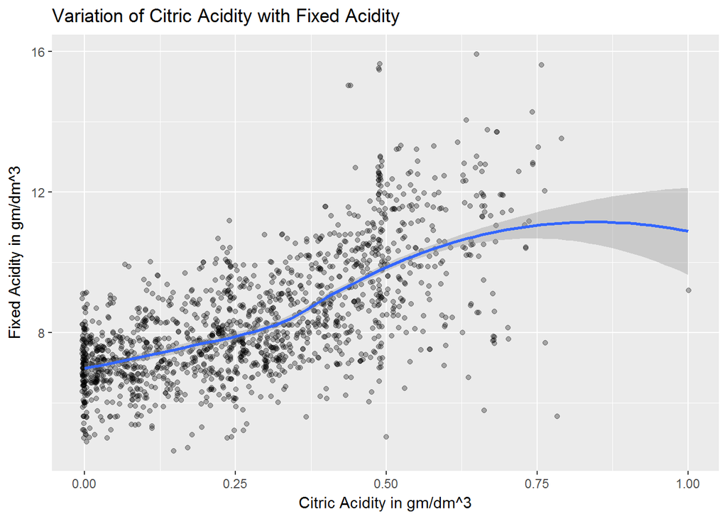

```r
#citric acide with fixed acidity

ggplot(aes(x = citric.acid,y = fixed.acidity),data = wine) +
  geom_jitter(alpha = 0.3) +
  ggtitle('Variation of Citric Acidity with Fixed Acidity') +
  xlab('Citric Acidity in gm/dm^3') +
  ylab('Fixed Acidity in gm/dm^3') +
  geom_smooth(method = 'loess')
```

As the quantity of citric acid has increased, Fixed acidity of wine has also Increased

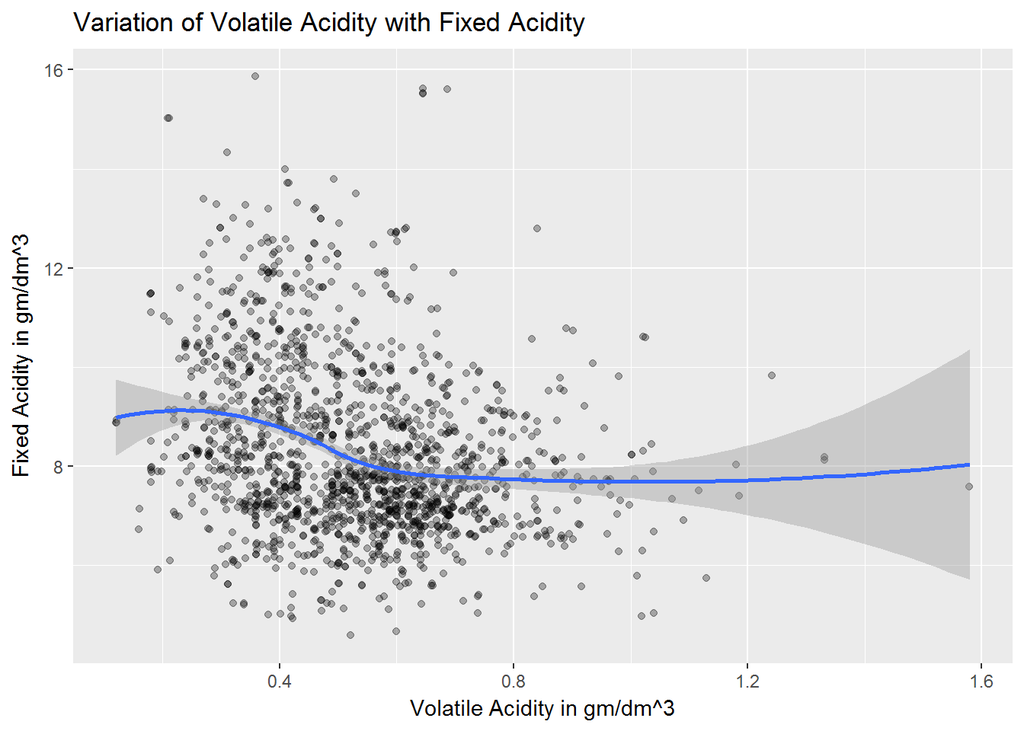

```r
#volatile acide with fixed acidity

ggplot(aes(x = volatile.acidity,y = fixed.acidity),data = wine) +
  geom_jitter(alpha = 0.3) +
  ggtitle('Variation of Volatile Acidity with Fixed Acidity') +
  xlab('Volatile Acidity in gm/dm^3') +
  ylab('Fixed Acidity in gm/dm^3') +
  geom_smooth(method = 'loess')
```

In this grapph as the volatile acidity increase the fixed acidity decreased first and then remained constant

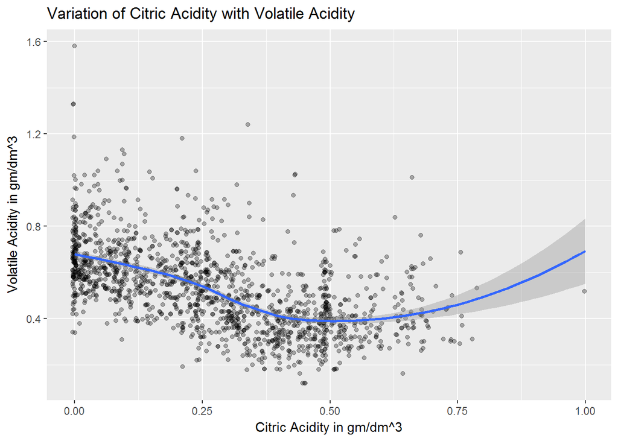

```r
# citric acidity with volatile acidity

ggplot(aes(x = citric.acid,y = volatile.acidity),data = wine) +
  geom_jitter(alpha = 0.3) +
  ggtitle('Variation of Citric Acidity with Volatile Acidity') +
  xlab('Citric Acidity in gm/dm^3') +
  ylab('Volatile Acidity in gm/dm^3') +
  geom_smooth(method = 'loess')
```

Over here as the amount of citric acide is inreasing , the volatile acidity firstly decreased and there is increase in it.

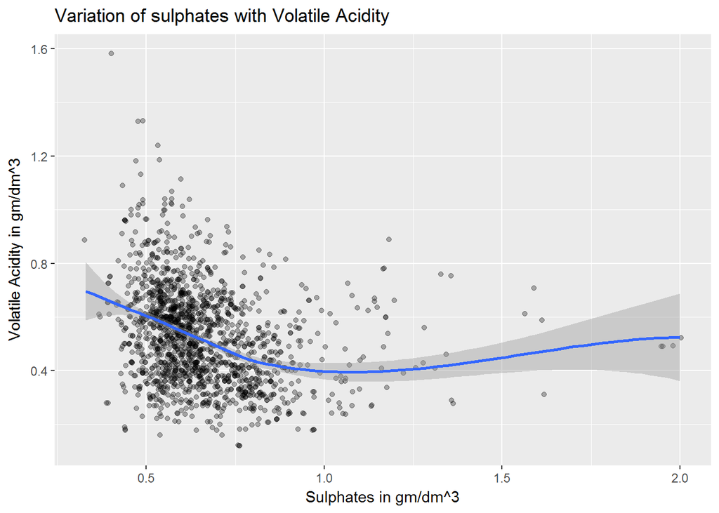

```r
# sulphates with volatile acidity

ggplot(aes(x = sulphates,y = volatile.acidity),data = wine) +
  geom_jitter(alpha = 0.3) +
  ggtitle('Variation of sulphates with Volatile Acidity') +
  xlab('Sulphates in gm/dm^3') +
  ylab('Volatile Acidity in gm/dm^3') +
  geom_smooth(method = 'loess')
```

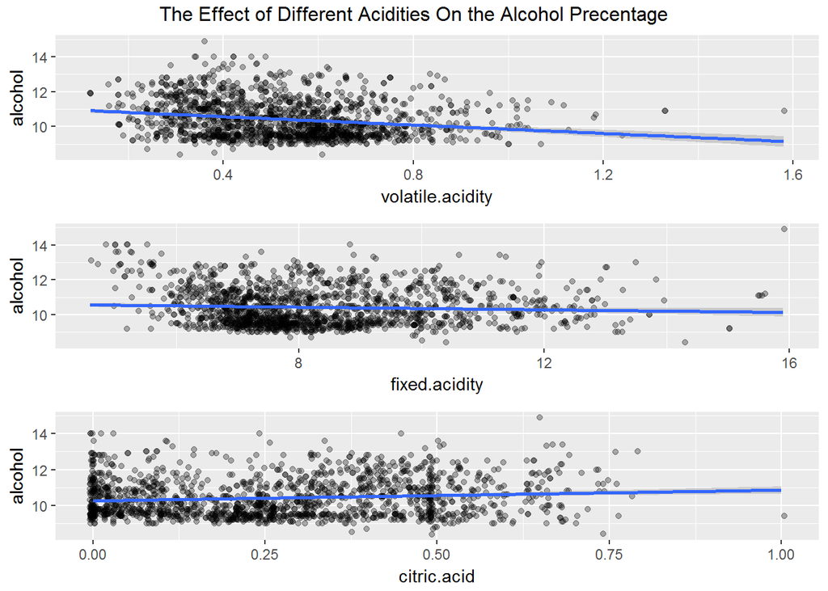

```r
tit = textGrob("The Effect of Different Acidities On the Alcohol Precentage")
p1 <- ggplot(aes(x = volatile.acidity,y = alcohol),data = wine) +
  geom_jitter(alpha = 0.3) +
  geom_smooth(method = 'lm')
p2 <- ggplot(aes(x = fixed.acidity,y = alcohol),data = wine) +
  geom_jitter(alpha = 0.3) +
  geom_smooth(method = 'lm')
p3 <- ggplot(aes(x = citric.acid,y = alcohol),data = wine) +
  geom_jitter(alpha = 0.3) +
  geom_smooth(method = 'lm')
grid.arrange(p1,p2,p3,ncol = 1,top = tit)
```